# Nanoblot

[figure not shown]

### NanoBlot: An R Package for Visualization of RNA Isoforms from Long Read RNA-sequencing Data

[figure not shown]

RT-PCR and Northern blots have long been used to study RNA isoforms usage for single genes. Recently, advancements in long read sequencing have yielded unprecedented information about the usage and abundance of these RNA isoforms. However, visualization of long-read sequencing data remains challenging due to the high information density. To alleviate these issues we have developed NanoBlot, a simple, open-source, command line tool, which generates Northern blot and RT-PCR-like images from third generation sequencing data. NanoBlot accepts processed bam files. Plotting is based around ggplot2 and is easily customizable. Advantages of NanoBlots include: designing probes to visualize isoforms which would be impossible with traditional RT-PCR or Northern blots, excluding reads from the Nanoblots based on the presence or absence of a specified region and, multiplexing plots with multiple colors. We present examples of Nanoblots compared to actual northern blot data. In addition to traditional gel-like images, NanoBlot also outputs other visualizations such as violin plots. The use of Nanoblot should provide a simple answer to the challenge of visualization of long-read RNA sequencing data.

## Basic Usage

The NanoBlot R package can be loaded entirely using the devtools package built into R. First, make sure that you have the devtools package in R.  
`install.packages("devtools")`

Then, make sure you are in the right directory for the R NanoBlot package folder, which should end in something like “/NanoBlotPackage”. Then, run this code to compile NanoBlot  
`devtools::install(build_vignettes = TRUE)` After installing, you can load the package using a simple library command

[output not shown]

[output not shown]

[output cut: 21 more lines]

chrXV 93395 94402 RPL18A_vw . -

[output not shown]

Here is an example of what the result of ampliconclip will look like in IGV. It subsets all reads that overlap with the start and end of the RPL18A gene, and then trims excess nucleotides for each read that lie outside that gene window.

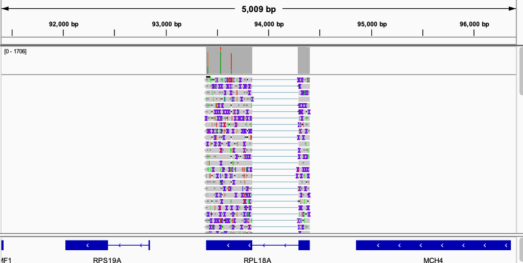

### RACE: Rapid Amplification of CDNA Ends

Alongside the RT-PCR subsetting, there is an added 3’ RACE (Rapid Amplification of CDNA Ends) option with the `RACE = TRUE` argument. It utilizes the same viewingWindow argument input to specify the genomic window of the RACE experiment. The only difference between RACE and RT-PCR is that whereas RT-PCR checks for inclusive ends on BOTH sides of the viewing window, RACE only checks for inclusive ends on ONE side of the viewing window, the 5’ end of the specified window. Conceptually, this makes sense as the RACE protocol is used to determine regions of unknown sequences. For example, a 3’ RACE experiment to determine unknown 3’ mRNA sequences that lie between the exon and the poly(A) tail uses a gene-specific primer that anneals to a region of known exon sequences and an adapter primer that targets the poly(A) tail. [^1] For more information on usage, read 3’ RACE protocols to see what you need. Reference manuscript for example usage.

### Checking Sample Integrity

An additional method we provide is for users to check a psuedo measure of their sample integrity based off of long-read sequencing data alone. This serves as a proxy to a measure like a RIN score analysis. The function `checkIntegrity` takes two arguments, one which is a GRanges object from the Genomic Ranges class which contains all the expected full length features, and a BamFileList object from the Rsamtools package which contains all the original non subsetted bam files.

The integrity function then goes through each individual feature in the GeneTargets argument and calculates the percentage of full length reads over total reads that map to that given feature. For a short diagram of this overlap, please reference the paper. The function then outputs a cumulative distribitution plot that visualizes each sample’s overall percetange of intact full length reads. A sample graph of this output is pictured down below.

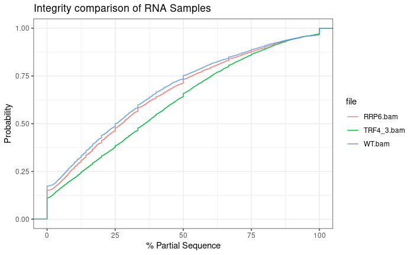

### R Plotting

Because Nanoblot deals with discrete read representations instead of continuous count numbers, the best way to visually represent the normalization is to duplicate the existing number of reads by a certain number that we call the duplication factor. This number is first calculated by taking the inverse of the size factor, since the size factor is divided during DeSeq2’s count normalization, and then multiplying the inversed number by 10 and rounding to the nearest digit to account for minimal data loss. Although this duplication factor would scale each sample respectively to their normalized counts, certain samples that inherently have lower reads than others would be visually hard to see. We then assigned an arbitrary **DUPLICATION_CONSTANT** a value of 2000 in order to scale all samples up or down respectively to ensure equal plotting exposure. This is essentially like automatically determining the exposure for Northern blots. The duplication factor from the previous step is then multiplied by taking the **DUPLICATION_CONSTANT** divided by the max number of reads across all samples plotted and rounded to the nearest integer. The plotting script then takes each sample’s reads and upscales it n times according to the duplication factor.

[^1]: “3´ RACE System for Rapid Amplification of CDNA Ends.” Thermo Fisher Scientific - US, https://www.thermofisher.com/us/en/home/references/protocols/nucleic-acid-amplification-and-expression-profiling/cdna-protocol/3-race-system-for-rapid-amplification-of-cdna-ends.html.